# Video 1: Bayesian Hypothesis Testing Concept

In this video we'll introduce the high-level concepts of Bayesian hypothesis testing and introduce several commonly used methods in Python code examples.

### Question 1: What is Bayesian Hypothesis Testing?

Hypothesis testing is a commonly used approach for engaging in statistical analysis. In statistics, a hypothesis is a premise, or a claim that we want to test or investigate, and one way we are going to investigate (we can't always go to a lab and do experiments) is that we can go ask a survey of several hundred people and get some data, and we can use those data as representative samples to study the population. So when we talk about hypothesis testing, or investigating on a claim, we are talking about doing some sampling, getting information, and then testing the hypothesis. So, much like in science we have an idea we have a problem and want to test that idea, in statistics, you have to pick out the hypothesis from reading the problem, and come up with a test that we want to investigate the problem. The goal of hypothesis testing, therefore, is to make decision based on what data would suggest what we want to investigate the problem. Back to the 1990s, the idea of coming up with Bayesian inference and deriving posterior density for analysis was a rocket science. It was frustrating experience to test claims solely with mathematics but not using efficient computational tools that nowadays we enjoy.

Now as probabilistic programming languages like PyMC3 and JAGS starts to blossom, Bayesian methods for estimation starts to prevail, and there's no exception for hypothesis testing.

### Question 2: What are different types of Bayesian Hypothesis Testing methods?

There are no one-size-fits-all way of conducting Bayesian hypothesis testing. However, all testing methods leverage 1) the prior distribution, 2) the likelihood function and 3) the posterior distribution derived from either the Bayes' rule or MCMC simulation to make any informed decision. This makes testing statistical claims under a combination of various knowledge sources instead of only depending on a single study, therefore Bayesian hypothesis testing uses more reliable evidence and should be more convincing.

### Question 3: What are null hypothesis and alternative hypothesis?

Okay! Now we've learnt what is conceptually a Bayesian hypothesis test. We know that for each hypothesis test we either have enough evidence to support a claim or do not have sufficient evidence to support a claim. Null hypothesis is the default hypothesis in which we would like to test against with evidence. For example, if we are finding evidence from data to support that gender inequality is happening in any part of the world, null hypothesis represents the default claim that there are no difference between genders. The alternative hypothesis is the opposite of the null hypothesis. In this case, the alternative hypothesis claims that there are gender inequality supported by the data. Therefore, each positive testing problem has a dual hypothesis - no hypothesis and the alternative hypothesis. Let's come back to our example. So we are testing the dual hypothesis as follows:

- Null hypothesis: We hypothesize that the salary distribution is equal between genders (Gender equality in salary distribution)
- Alternative hypothesis: we want to find evidence to prove that the salary distribution is unequal between genders (Gender inequality in salary distribution)

### Question 4: What are different categories of hypotheses testing?

For example, gender equality has raised tremendous dialogue and campaigns among the world. It is the state of equal ease of access to resources and opportunities regardless of gender, including economic participation and decision-making. If you want to figure out if female employees are paid less than male employees in a certain country, or area, you are involved in a **two-sample one-sided hypothesis testing**. The definition of two sample means that we use two samples in testing the hypothesis - the male employee sample, and the female employee sample. Chances are that your claim is bolstered by data evidence, or your claim is not supported by the data. However, if you want to prove that if female employees are paid either much more than, or much less than male employees in a certain country, then you are conducting a **two-sample two-sided hypothesis testing**. Chances are that the your claim is supported because either female employees are paid too low or too high compared to the male employees, and otherwise your claim does not have sufficient evidence to support because the salaries might be just slightly different between genders; and the difference is not substantial.

No one could actually foresee the result of hypothesis testing, let alone the variability of the evidence, until we can write scripts to combine our prior thinking and the data samples such that the Bayesian model is implemented.

Hopefully you enjoyed the video and learned something meaningful about Bayesian hypothesis testing. Let's start to code in the next video!

# Video 2: Bayesian Hypothesis Testing - Group Comparison

In this lecture, we'll dive into several research questions regarding the gender equality issues for testing a hypothesis in campus placement. We basically compare a different group of inputs and see the posterior distribution are they significantly different from each other. Do they have overlaps? Let's start coding!

```python
# https://www.kaggle.com/duncankmckinnon/statistics-of-campus-placement-data
# So let's import several useful packages for data science, pandas, seaborn, numpy and matplotlib

import pandas as pd
import seaborn as sns
import numpy as np
import matplotlib.pyplot as plt

# Campus recruitment data is often recorded for many universities because it is a strategy to engage, source
# and hire talented students and recent graduates for internship or entry-level positions.
# These recruitment might take place in career fairs and placement seasons.

# Now let's read the campus placement data from the assets folder
placement = pd.read_csv("assets/placement_data_full_class.csv")
# and take a look!
placement

# You see that we have a rich data here. This data set consists of placement records of 215 students in
# a university campus in India aåccording to Kaggle.
# It includes secondary and higher secondary school percentage and specialization.
# It also includes degree specialization, type and Work experience and salary offers to the placed students
```

|  | sl_no | gender | ssc_p | ssc_b | hsc_p | hsc_b | hsc_s | degree_p | degree_t | workex | etest_p | specialisation | mba_p | status | salary |
| --- | --- | --- | --- | --- | --- | --- | --- | --- | --- | --- | --- | --- | --- | --- | --- |
| 0 | 1 | M | 67.00 | Others | 91.00 | Others | Commerce | 58.00 | Sci&Tech | No | 55.0 | Mkt&HR | 58.80 | Placed | 270000.0 |
| 1 | 2 | M | 79.33 | Central | 78.33 | Others | Science | 77.48 | Sci&Tech | Yes | 86.5 | Mkt&Fin | 66.28 | Placed | 200000.0 |
| 2 | 3 | M | 65.00 | Central | 68.00 | Central | Arts | 64.00 | Comm&Mgmt | No | 75.0 | Mkt&Fin | 57.80 | Placed | 250000.0 |
| 3 | 4 | M | 56.00 | Central | 52.00 | Central | Science | 52.00 | Sci&Tech | No | 66.0 | Mkt&HR | 59.43 | Not Placed | NaN |
| 4 | 5 | M | 85.80 | Central | 73.60 | Central | Commerce | 73.30 | Comm&Mgmt | No | 96.8 | Mkt&Fin | 55.50 | Placed | 425000.0 |
| ... | ... | ... | ... | ... | ... | ... | ... | ... | ... | ... | ... | ... | ... | ... | ... |
| 210 | 211 | M | 80.60 | Others | 82.00 | Others | Commerce | 77.60 | Comm&Mgmt | No | 91.0 | Mkt&Fin | 74.49 | Placed | 400000.0 |
| 211 | 212 | M | 58.00 | Others | 60.00 | Others | Science | 72.00 | Sci&Tech | No | 74.0 | Mkt&Fin | 53.62 | Placed | 275000.0 |
| 212 | 213 | M | 67.00 | Others | 67.00 | Others | Commerce | 73.00 | Comm&Mgmt | Yes | 59.0 | Mkt&Fin | 69.72 | Placed | 295000.0 |
| 213 | 214 | F | 74.00 | Others | 66.00 | Others | Commerce | 58.00 | Comm&Mgmt | No | 70.0 | Mkt&HR | 60.23 | Placed | 204000.0 |
| 214 | 215 | M | 62.00 | Central | 58.00 | Others | Science | 53.00 | Comm&Mgmt | No | 89.0 | Mkt&HR | 60.22 | Not Placed | NaN |

215 rows × 15 columns

### Data Variable Description:

Here our data has 215 records and 15 columns in total to and let's see the data verbal description list.

- **sl_no**: Serial Number
- **gender**: Gender- Male='M',Female='F'
- **ssc_p**: Secondary Education percentage- 10th Grade
- **ssc_b**: Board of Education- (Central/ Others)
- **hsc_p**: Higher Secondary Education percentage- 12th Grade
- **hsc_b**: Board of Education- (Central/ Others)
- **hsc_s**: Specialization in Higher Secondary Education
- **degree_p**: Degree Percentage
- **degree_t**: Under Graduation(Degree type)- Field of degree education
- **workex**: Work Experience
- **etest_p**: Employability test percentage (conducted by college)
- **specialisation**: Post Graduation(MBA)- Specialization
- **mba_p**: MBA percentage
- **status**: Status of placement- (Placed/Not placed)
- **salary**: Salary offered by corporate to candidates

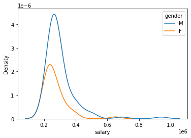

```python
# We can visually inspect like does Gender affect salary. We can draw a kernel density plot
sns.kdeplot(data = placement, x = 'salary', hue = 'gender')

# The graph shows that:
# 1. Most of the candidates scored around 60 percentage got a decent package of around 3 lakhs PA
# 2. Not many candidates received salary more than 4 lakhs PA
```

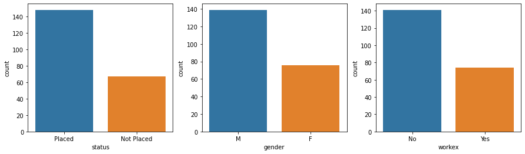

```python
# We can draw 3 subplots in the figure to show the proportions of placed job, gender and prior working experience -
# there are numerous ways to do this but specifying fig and ax objects work fine.
fig, ax =plt.subplots(1,3, figsize = (15,4))
sns.countplot(placement['status'], ax = ax[0])
sns.countplot(placement['gender'], ax = ax[1])
sns.countplot(placement['workex'], ax = ax[2])

# We find interesting patterns in these three visualizations
# 1. There are more people placed with a job than they're not placed
# 2. There are more males recorded in this data set than females
# 3. There are higher proportion of people with no prior work experience than yes
```

```python
# Although we can generate graphs for each factors that we are interested, now status, gender and workex
# are still categorical, so we can't directly use them for model unless we attribute them values, such
# as attributing 0 for female, and 1 for male candidates. This actually can be achieved by label encoding:

# Although is the first time to use a label encoder, I want to import sklearn label encoder.
from sklearn.preprocessing import LabelEncoder

# It's an one-line encoder to transform binary categorical variables into 0 and 1.
# We can apply the label encoder function for the category which has only two types of classes

# Apply label encoder to each column with categorical data
label_encoder = LabelEncoder()

# We create a list of categorical variables that we're going to transform
object_cols = ['gender', 'workex', 'status']
# and write a for loop for col in all object columns,
for col in object_cols:
    # We call the label_encoder to transform the object column into 0-1 binary form
    placement[col] = label_encoder.fit_transform(placement[col])

# and now we see the data again.
placement.head()

# OK now you see the gender variable, the work experience variable, as well as the status variable
# are labeled zero and one, they all become binary.
```

|  | sl_no | gender | ssc_p | ssc_b | hsc_p | hsc_b | hsc_s | degree_p | degree_t | workex | etest_p | specialisation | mba_p | status | salary |
| --- | --- | --- | --- | --- | --- | --- | --- | --- | --- | --- | --- | --- | --- | --- | --- |
| 0 | 1 | 1 | 67.00 | Others | 91.00 | Others | Commerce | 58.00 | Sci&Tech | 0 | 55.0 | Mkt&HR | 58.80 | 1 | 270000.0 |
| 1 | 2 | 1 | 79.33 | Central | 78.33 | Others | Science | 77.48 | Sci&Tech | 1 | 86.5 | Mkt&Fin | 66.28 | 1 | 200000.0 |
| 2 | 3 | 1 | 65.00 | Central | 68.00 | Central | Arts | 64.00 | Comm&Mgmt | 0 | 75.0 | Mkt&Fin | 57.80 | 1 | 250000.0 |
| 3 | 4 | 1 | 56.00 | Central | 52.00 | Central | Science | 52.00 | Sci&Tech | 0 | 66.0 | Mkt&HR | 59.43 | 0 | NaN |
| 4 | 5 | 1 | 85.80 | Central | 73.60 | Central | Commerce | 73.30 | Comm&Mgmt | 0 | 96.8 | Mkt&Fin | 55.50 | 1 | 425000.0 |

### Research Questions:

In this tutorial, we'll analyze a data about campus recruitment to answer -

- **Does Gender affect salary?**
- **Does Gender affect the probability of placement?**

```python
# Let's import the pymc3 and arviz package to make a model call.
import pymc3 as pm
import arviz as az

# Research question 1: Does gender affect salary?

# I recommend a good practice before starting to model in tutorials to subset the data properly
# and save them into different variables. We first store the salary for men employees with gender equals to 1.
salary_male = placement[placement['gender'] == 1]['salary']
# and store another variable call salary female with the salary for women employees with gender equal to 0.
salary_female = placement[placement['gender'] == 0]['salary']

# Again, we enwrap the model now using a meaningful variable name called gender_salary hypothesis testing
with pm.Model() as gender_salary_ht:

    # We can specify the prior of the mean obtaining degree as the normal distribution as prior and
    # let's set 60 as mean and 5 as standard deviation
    # Assume same salary for both genders, and let's set the salary as 300,000 and standard deviation
    # as 50,000 for both mu_male and mu_female
    mu_male = pm.Normal('mu_male', mu = 300000, sigma = 50000)
    mu_female = pm.Normal('mu_female', mu = 300000, sigma = 50000)

    # It's interesting to understand more the signa - the stabdard deviation. It tells you how much spread
    # you can see in the salary for individuals with placement, so we got an absolute minimum of 0 -
    # where all people just have the same salary with a placement on jobs.
    sigma = pm.HalfNormal('sigma', 20000)

    # Hypothesis: Same salary level between genders
    salary_diff = pm.Deterministic('salary_diff', mu_male - mu_female)

    # Likelihood: We're here conducting hypothesis testing, so we need to create both male and female
    # estimates to compare their difference based on our data subsetted for male and female.
    y_male = pm.Normal('y_male', mu = mu_male, sigma = sigma, observed = salary_male)
    y_female = pm.Normal('y_female', mu = mu_female, sigma = sigma, observed = salary_female)

    trace = pm.sample(3000, chains = 3, tune = 500)

    # Take a coffee break for 30 seconds
```

100.00% [10500/10500 00:05<00:00 Sampling 3 chains, 0 divergences]

```
Sampling 3 chains for 500 tune and 3_000 draw iterations (1_500 + 9_000 draws total) took 16 seconds.
```